# Simulation o

## 2.1. constructed relationship

### 2.1.1 first trial vs dishab

Confirm the constructed relationship

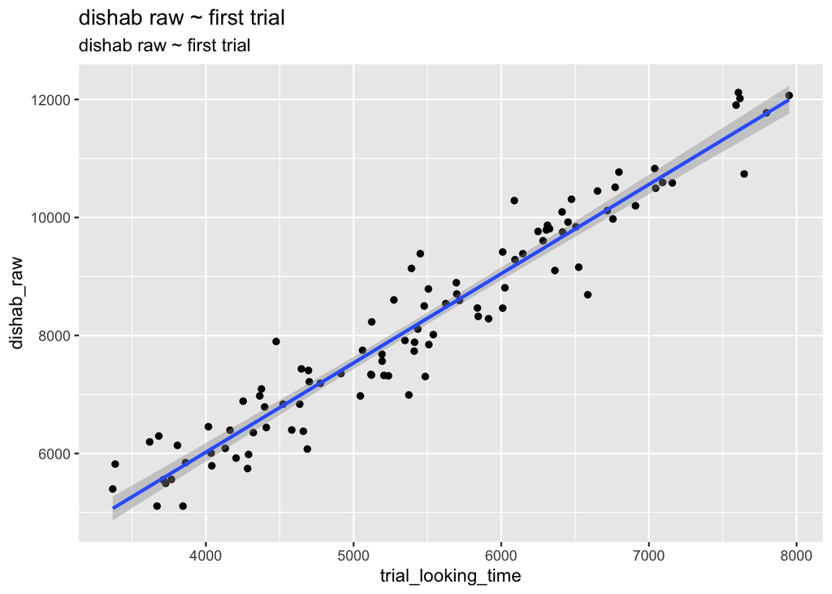

```r
adult_dishab_raw %>%
  select(subject,block_number, trial_looking_time) %>%
  rename(dishab_raw = trial_looking_time) %>%
  left_join(
    fake_data_fist_trial  %>% filter(trial_number == 1),
    by = c("subject", "block_number")
  ) %>%
  ggplot(aes(x = trial_looking_time, y = dishab_raw)) +
  geom_point() +
  geom_smooth(method = "lm") +
  labs(
    title = "dishab raw ~ first trial",
    subtitle = "dishab raw ~ first trial"
  )
```

### 2.1.2 last trial vs dishab raw

Checking the impact on the last trial and the dishab raw, there’s an impact

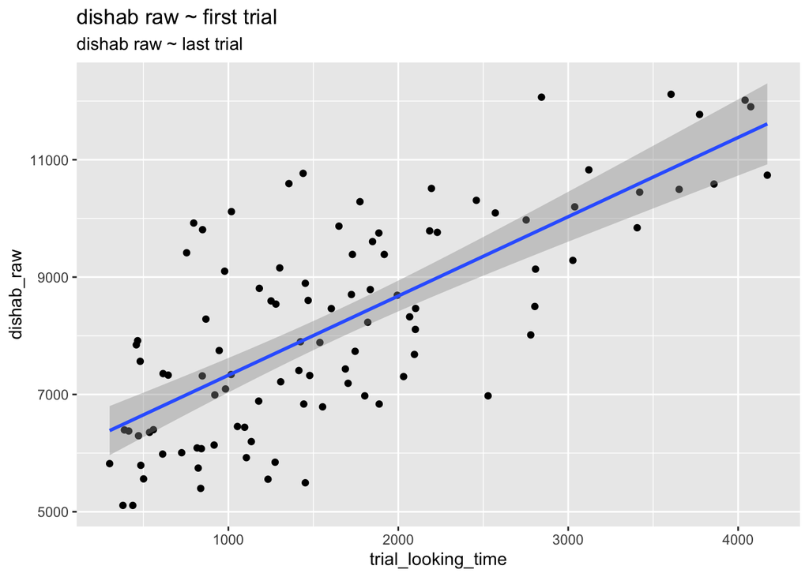

```r
adult_dishab_raw %>%
  select(subject,block_number, trial_looking_time) %>%
  rename(dishab_raw = trial_looking_time) %>%
  left_join(
    fake_data_fist_trial  %>% group_by(subject) %>% filter(trial_number == (max(trial_number) -1)),
    by = c("subject", "block_number")
  ) %>%
  ggplot(aes(x = trial_looking_time, y = dishab_raw)) +
  geom_point() +
  geom_smooth(method = "lm") +
   labs(
    title = "dishab raw ~ first trial",
    subtitle = "dishab raw ~ last trial"
  )
```

## 2.2 slope?!?!

Explores the relationship between decay rate and dishabituation difference, negative relationship

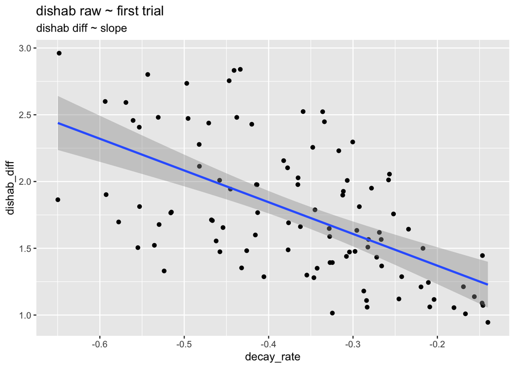

```r
adult_dishab_d %>%
  left_join(adult_slope_df) %>%
  ggplot(aes(x = decay_rate, y = dishab_diff)) +
  geom_point() +
  geom_smooth(method = "lm") +
  labs(
    title = "dishab raw ~ first trial",
    subtitle = "dishab diff ~ slope"
  )
```

# 3. Confounding: slope and dishabituation directly related

Generates data where the deviant trial is explicitly related to the decay rate – this is kind of what we want to see in the dataset

```r
# Set seed for reproducibility
set.seed(123)

# Generate synthetic data
generate_fake_data <- function(n_subjects = 50) {
  # Create subject IDs
  subjects <- paste0("S", sprintf("%03d", 1:n_subjects))

  # Initialize empty data frame
  data <- data.frame()

  # Loop through each subject
  for (subj in subjects) {
    # Randomly assign number of habituation trials (4 or 6)
    n_trials <- sample(c(4, 6), 1)
    trial_number <- 1:(n_trials + 1)

    # Simulate exponential drop in habituation times with varying slopes
    initial_looking_time <- runif(1, 5000, 10000)
    decay_rate <- runif(1, 0.2, 0.5)  # Randomly vary decay rate
    habituation_times <- initial_looking_time * exp(-decay_rate * (1:n_trials))
    deviant_time <- 10000 * decay_rate + rnorm(1, 0, 500)  # Linearly related to the decay slope

    # Combine looking times
    trial_looking_time <- c(habituation_times, deviant_time)

    # Assign trial types
    trial_type <- c(rep('background', n_trials), 'deviant')

    # Create data frame for subject
    subject_data <- data.frame(
      subject = subj,
      block_number = 1,
      task_type = 'curiosity',
      deviant_position = n_trials + 1,
      trial_number = trial_number,
      trial_type = trial_type,
      trial_looking_time = trial_looking_time,
      stimulus_displayed = paste0('images/stimuli/', sample(1:20, n_trials + 1, replace = TRUE), '_A_a.gif'),
      task_question_type = 'curiosity_background',
      task_question_response = sample(1:5, n_trials + 1, replace = TRUE)
    )

    # Append subject data
    data <- rbind(data, subject_data)
  }

  return(data)
}

# Generate dataset
fake_data_slope <- generate_fake_data(n_subjects = 50)
```

```r
habituation_data <-  fake_data_slope %>%
  # fist block
  # before the dishabituation trials
  filter(trial_number < deviant_position) %>%
  # only keeping the relevant information
  select(subject, trial_number, trial_looking_time)

adult_slope_df <- get_individual_slope(habituation_data)



adult_dishab_raw <- fake_data_slope %>%
  filter(trial_number == deviant_position)

adult_dishab_d <- adult_dishab_raw %>%
  select(subject,block_number, trial_looking_time) %>%
  rename(dishab_raw = trial_looking_time) %>%
  left_join(
    fake_data_slope  %>% filter(trial_number < deviant_position) %>% group_by(subject, block_number) %>% filter(trial_number == max(trial_number)),
    by = c("subject", "block_number")
  ) %>%
  # calculating the key
  mutate(dishab_diff = log(dishab_raw) - log(trial_looking_time)) %>%
  mutate(dishab_trial_num = trial_number + 1) %>%
  select(subject, dishab_diff, dishab_trial_num)
```

## 3.1. relationships

Tests correlations between first/last trials and dishabituation time

### 3.1.1 first trial vs dishab

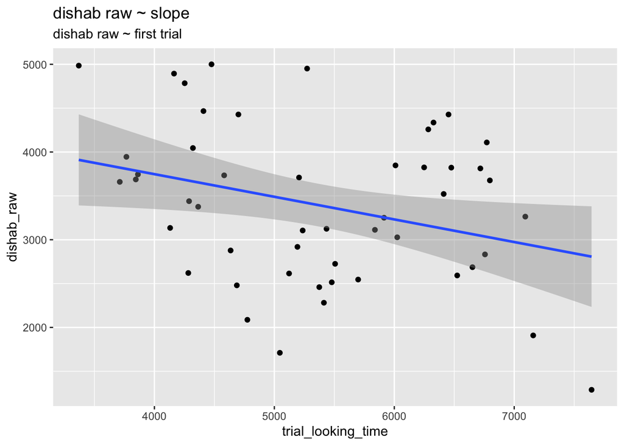

```r
adult_dishab_raw %>%
  select(subject,block_number, trial_looking_time) %>%
  rename(dishab_raw = trial_looking_time) %>%
  left_join(
    fake_data_slope  %>% filter(trial_number == 1),
    by = c("subject", "block_number")
  ) %>%
  ggplot(aes(x = trial_looking_time, y = dishab_raw)) +
  geom_point() +
  geom_smooth(method = "lm") +
  labs(
    title = "dishab raw ~ slope",
    subtitle = "dishab raw ~ first trial"
  )
```

### 3.1.2 last trial vs dishab raw

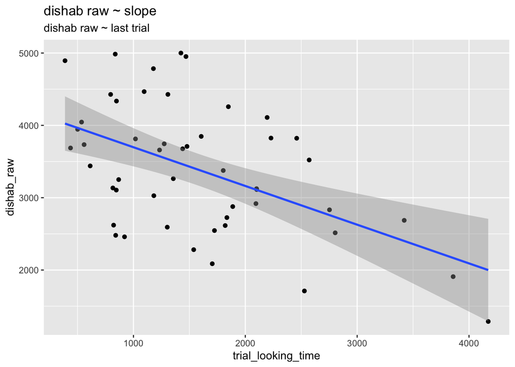

```r
adult_dishab_raw %>%
  select(subject,block_number, trial_looking_time) %>%
  rename(dishab_raw = trial_looking_time) %>%
  left_join(
    fake_data_slope  %>% group_by(subject) %>% filter(trial_number == (max(trial_number) -1)),
    by = c("subject", "block_number")
  ) %>%
  ggplot(aes(x = trial_looking_time, y = dishab_raw)) +
  geom_point() +
  geom_smooth(method = "lm") +
  labs(
    title = "dishab raw ~ slope",
    subtitle = "dishab raw ~ last trial"
  )
```

## 3.2 slope?!?

decay rate and dishabituation difference

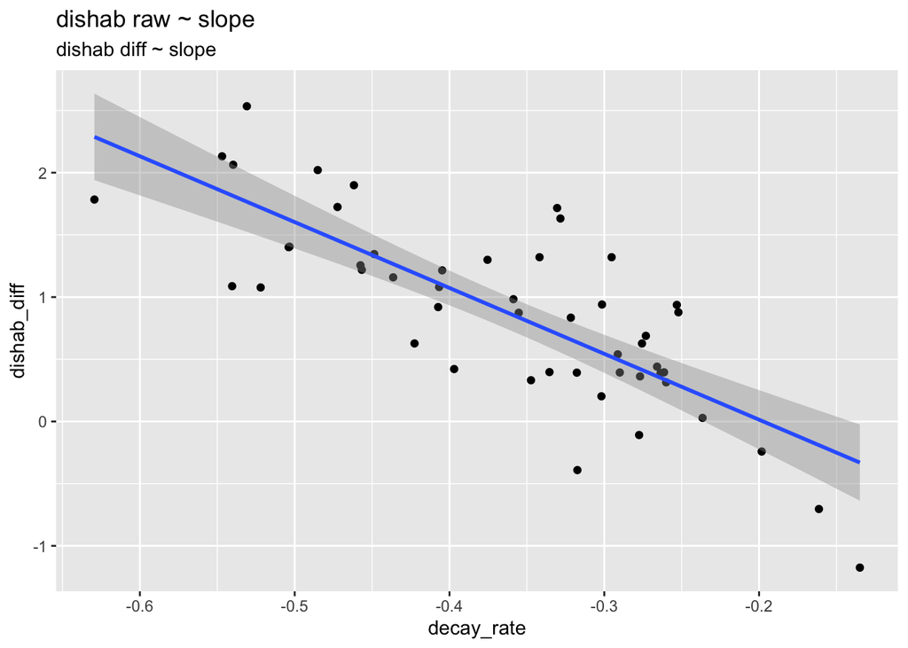

```r
adult_dishab_d %>%
  left_join(adult_slope_df) %>%
  ggplot(aes(x = decay_rate, y = dishab_diff)) +
  geom_point() +
  geom_smooth(method = "lm") +
  labs(
    title = "dishab raw ~ slope",
    subtitle = "dishab diff ~ slope"
  )
```

# 4. non-confounding relationship

Now let’s create a dataset that the dishabituation time is arbitrarily high

```r
# Set seed for reproducibility
set.seed(123)

# Generate synthetic data
generate_fake_data <- function(n_subjects = 50) {
  # Create subject IDs
  subjects <- paste0("S", sprintf("%03d", 1:n_subjects))

  # Initialize empty data frame
  data <- data.frame()

  # Loop through each subject
  for (subj in subjects) {
    # Randomly assign number of habituation trials (4 or 6)
    n_trials <- sample(c(4, 6), 1)
    trial_number <- 1:(n_trials + 1)

    # Simulate exponential drop in habituation times with varying slopes
    initial_looking_time <- runif(1, 5000, 10000)
    decay_rate <- runif(1, 0.2, 0.5)  # Randomly vary decay rate
    habituation_times <- initial_looking_time * exp(-decay_rate * (1:n_trials))
    deviant_time <- runif(1, 10000, 15000)  # Arbitrarily high but independent of previous trials

    # Combine looking times
    trial_looking_time <- c(habituation_times, deviant_time)

    # Assign trial types
    trial_type <- c(rep('background', n_trials), 'deviant')

    # Create data frame for subject
    subject_data <- data.frame(
      subject = subj,
      block_number = 1,
      task_type = 'curiosity',
      deviant_position = n_trials + 1,
      trial_number = trial_number,
      trial_type = trial_type,
      trial_looking_time = trial_looking_time,
      stimulus_displayed = paste0('images/stimuli/', sample(1:20, n_trials + 1, replace = TRUE), '_A_a.gif'),
      task_question_type = 'curiosity_background',
      task_question_response = sample(1:5, n_trials + 1, replace = TRUE)
    )

    # Append subject data
    data <- rbind(data, subject_data)
  }

  return(data)
}

# Generate dataset
fake_data_nr <- generate_fake_data(n_subjects = 50)
```

```r
habituation_data <-  fake_data_nr %>%
  # fist block
  # before the dishabituation trials
  filter(trial_number < deviant_position) %>%
  # only keeping the relevant information
  select(subject, trial_number, trial_looking_time)

adult_slope_df <- get_individual_slope(habituation_data)



adult_dishab_raw <- fake_data_nr %>%
  filter(trial_number == deviant_position)

adult_dishab_d <- adult_dishab_raw %>%
  select(subject,block_number, trial_looking_time) %>%
  rename(dishab_raw = trial_looking_time) %>%
  left_join(
    fake_data_nr  %>% filter(trial_number < deviant_position) %>% group_by(subject, block_number) %>% filter(trial_number == max(trial_number)),
    by = c("subject", "block_number")
  ) %>%
  # calculating the key
  mutate(dishab_diff = log(dishab_raw) - log(trial_looking_time)) %>%
  mutate(dishab_trial_num = trial_number + 1) %>%
  select(subject, dishab_diff, dishab_trial_num)
```

## 4.1. relationships

### 4.1.1 first trial vs dishab

check the relationship between first trial and dishabituation

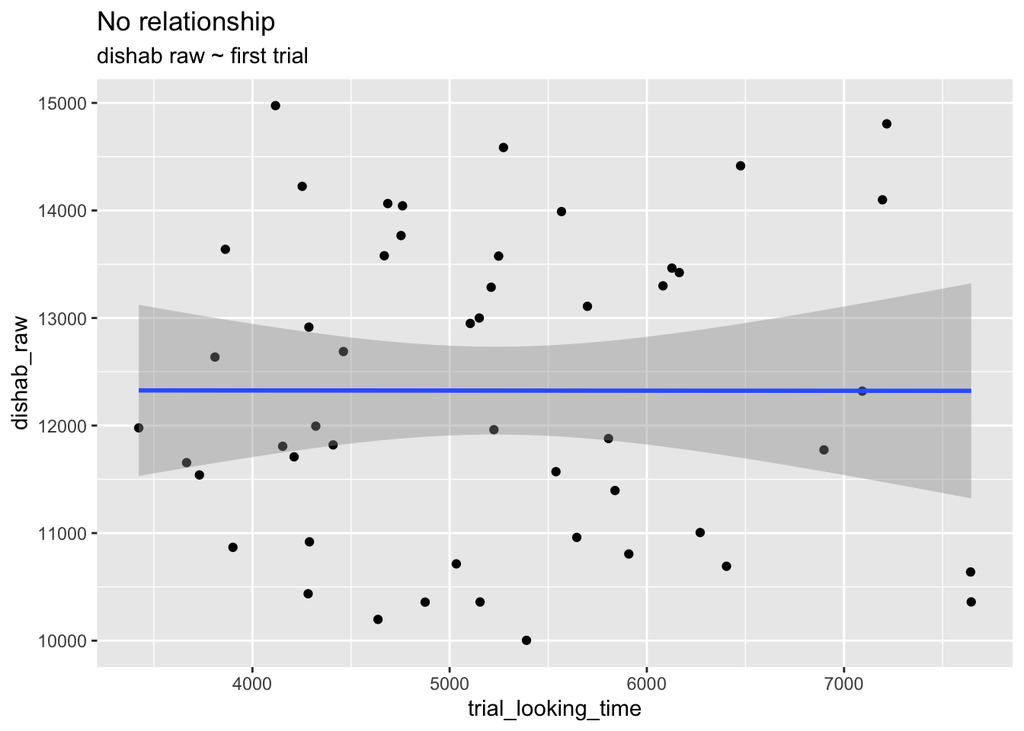

```r
adult_dishab_raw %>%
  select(subject,block_number, trial_looking_time) %>%
  rename(dishab_raw = trial_looking_time) %>%
  left_join(
    fake_data_nr  %>% filter(trial_number == 1),
    by = c("subject", "block_number")
  ) %>%
  ggplot(aes(x = trial_looking_time, y = dishab_raw)) +
  geom_point() +
  geom_smooth(method = "lm") +
  labs(
    title = "No relationship",
    subtitle = "dishab raw ~ first trial"
  )
```

### 4.1.2 last trial vs dishab

check the relationship between last trial and dishabituation

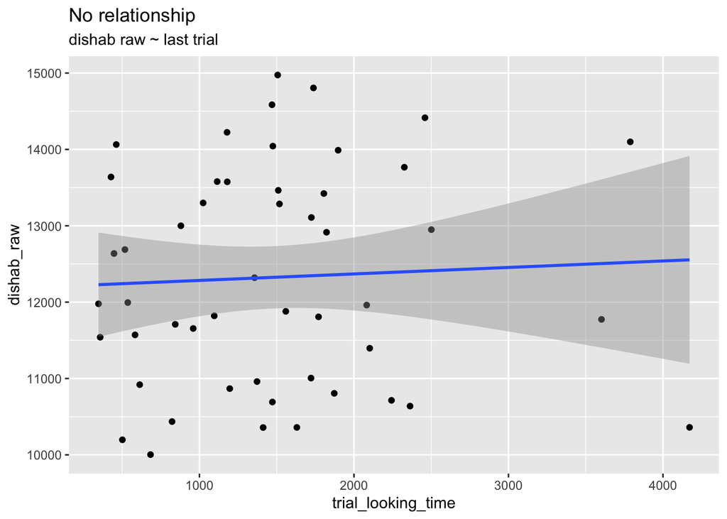

```r
adult_dishab_raw %>%
  select(subject,block_number, trial_looking_time) %>%
  rename(dishab_raw = trial_looking_time) %>%
  left_join(
    fake_data_nr  %>% group_by(subject) %>% filter(trial_number == (max(trial_number) -1)),
    by = c("subject", "block_number")
  ) %>%
  ggplot(aes(x = trial_looking_time, y = dishab_raw)) +
  geom_point() +
  geom_smooth(method = "lm") +
   labs(
    title = "No relationship",
    subtitle = "dishab raw ~ last trial"
  )
```

## 4.2 slope?!?

yet still there exists a relationship between the slope and the dishabituation difference

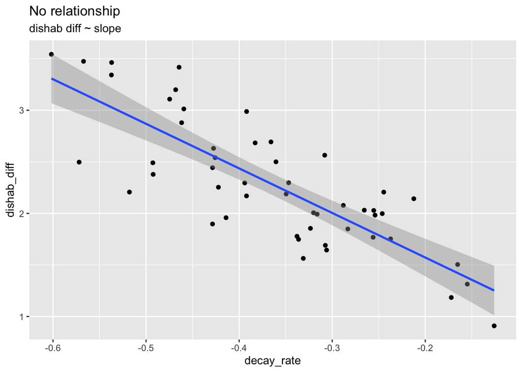

```r
adult_dishab_d %>%
  left_join(adult_slope_df) %>%
  ggplot(aes(x = decay_rate, y = dishab_diff)) +
  geom_point() +
  geom_smooth(method = "lm") +
  labs(
    title = "No relationship",
    subtitle = "dishab diff ~ slope"
  )
```

## 4.3 raw data

weird, what does it look like?

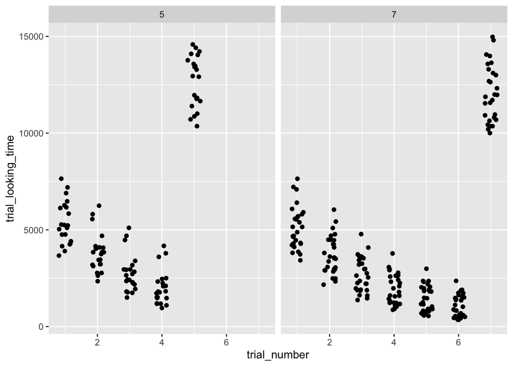

```r
fake_data_nr %>%
  ggplot(aes(x = trial_number, y = trial_looking_time)) +
  geom_point(position = position_jitter(width = .2)) +
  facet_wrap(~deviant_position)
```

## 4.4. why the relationship?

1. The last habituation trial value depends inversely on the decay rate (higher decay → smaller last trial values).
2. The dishabituation difference is computed as a logarithmic ratio involving the last trial time. When t_last is smaller (due to a higher decay rate), the log difference grows larger, creating a spurious correlation.

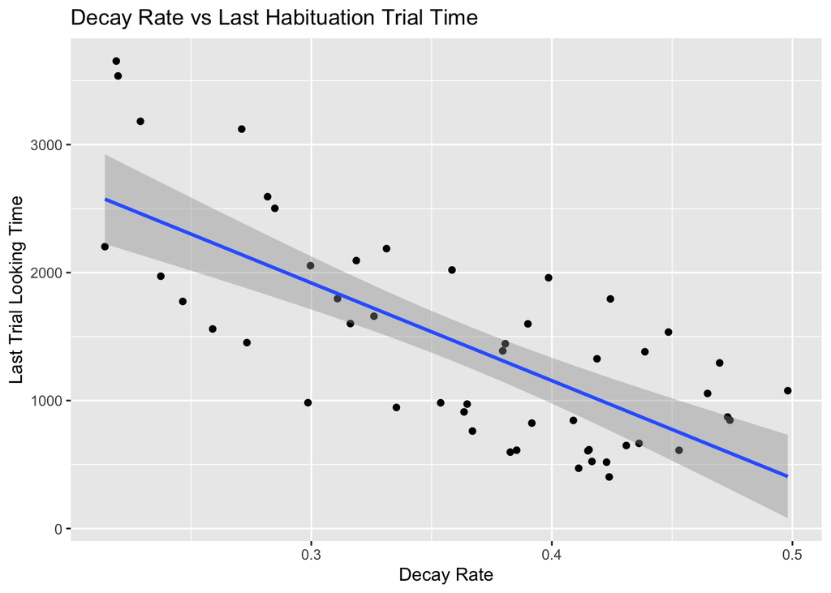

```r
# Generate synthetic data
generate_fake_data <- function(n_subjects = 50) {
  # Create subject IDs
  subjects <- paste0("S", sprintf("%03d", 1:n_subjects))

  # Initialize empty data frame
  data <- data.frame()

  # Loop through each subject
  for (subj in subjects) {
    # Randomly assign number of habituation trials (4 or 6)
    n_trials <- sample(c(4, 6), 1)
    trial_number <- 1:(n_trials + 1)

    # Simulate exponential drop in habituation times with varying slopes
    initial_looking_time <- runif(1, 5000, 10000)
    decay_rate <- runif(1, 0.2, 0.5)  # Randomly vary decay rate
    habituation_times <- initial_looking_time * exp(-decay_rate * (1:n_trials))

    # Make the deviant trial completely independent by adding a large random value
    deviant_time <- runif(1, 15000, 20000)  # Arbitrarily high but independent of previous trials

    # Combine looking times
    trial_looking_time <- c(habituation_times, deviant_time)

    # Assign trial types
    trial_type <- c(rep('background', n_trials), 'deviant')

    # Create data frame for subject
    subject_data <- data.frame(
      subject = subj,
      block_number = 1,
      task_type = 'curiosity',
      deviant_position = n_trials + 1,
      trial_number = trial_number,
      trial_type = trial_type,
      trial_looking_time = trial_looking_time,
      decay_rate = decay_rate,  # Include decay rate for analysis
      stimulus_displayed = paste0('images/stimuli/', sample(1:20, n_trials + 1, replace = TRUE), '_A_a.gif'),
      task_question_type = 'curiosity_background',
      task_question_response = sample(1:5, n_trials + 1, replace = TRUE)
    )

    # Append subject data
    data <- rbind(data, subject_data)
  }

  return(data)
}

# Generate dataset
fake_data <- generate_fake_data(n_subjects = 50)

# Visualization: Relationship between decay rate and last trial time
last_trial_data <- fake_data %>%
  group_by(subject) %>%
  filter(trial_number == max(trial_number) - 1)  # Select last habituation trial

# Plot decay rate vs last trial looking time
ggplot(last_trial_data, aes(x = decay_rate, y = trial_looking_time)) +
  geom_point() +
  geom_smooth(method = 'lm') +
  labs(
    title = 'Decay Rate vs Last Habituation Trial Time',
    x = 'Decay Rate',
    y = 'Last Trial Looking Time'
  )
```

## 4.5 try normalizing by the first trial???

still doesn’t work. even though the deviant time is independent, the first trial indirectly scales the entire decay trajectory. Here’s the subtle issue:

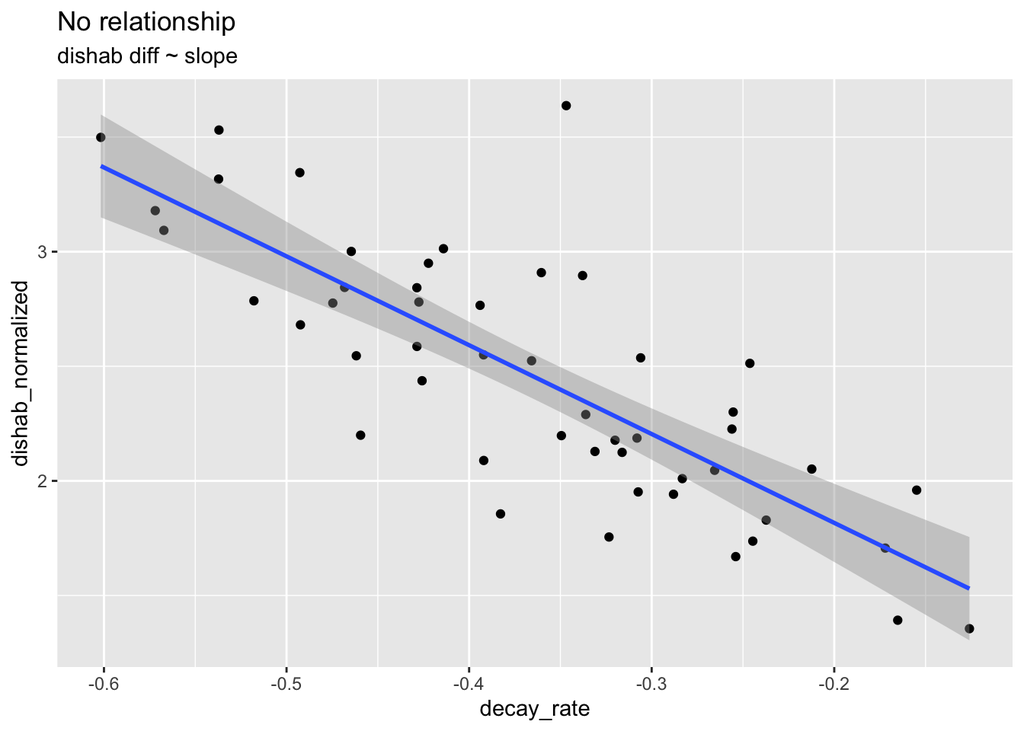

```r
adult_dishab_d <- adult_dishab_raw %>%
  select(subject,block_number, trial_looking_time) %>%
  rename(dishab_raw = trial_looking_time) %>%
  left_join(
    fake_data_nr  %>% filter(trial_number < deviant_position) %>% group_by(subject, block_number) %>% filter(trial_number == max(trial_number)),
    by = c("subject", "block_number")
  ) %>%
  left_join(
    fake_data_nr %>% group_by(subject, block_number)  %>% filter(trial_number == 1) %>% rename(first_trial_looking_time = trial_looking_time) %>% select(subject, block_number, first_trial_looking_time)
,
    by = c("subject", "block_number")
  ) %>%
  # calculating the key
  mutate(
    dishab_diff = log(dishab_raw) - log(trial_looking_time),
    dishab_normalized = (dishab_raw / first_trial_looking_time)) %>%
  mutate(dishab_trial_num = trial_number + 1) %>%
  select(subject, dishab_diff, dishab_normalized, dishab_trial_num, first_trial_looking_time)

adult_dishab_d %>%
  left_join(adult_slope_df) %>%
  ggplot(aes(x = decay_rate, y = dishab_normalized)) +
  geom_point() +
  geom_smooth(method = "lm") +
  labs(
    title = "No relationship",
    subtitle = "dishab diff ~ slope"
  )
```

## 4.6 try modeling

```r
model_d <- adult_dishab_d %>%
  left_join(adult_slope_df)
lm(
  dishab_diff ~ decay_rate,
  data = model_d
) %>% summary()
```

```
##
## Call:
## lm(formula = dishab_diff ~ decay_rate, data = model_d)
##
## Residuals:
##      Min       1Q   Median       3Q      Max
## -0.73879 -0.27604  0.00625  0.29323  0.70181
##
## Coefficients:
##             Estimate Std. Error t value Pr(>|t|)
## (Intercept)   0.7079     0.1729   4.094 0.000162 ***
## decay_rate   -4.3211     0.4526  -9.547 1.13e-12 ***
## ---
## Signif. codes:  0 '***' 0.001 '**' 0.01 '*' 0.05 '.' 0.1 ' ' 1
##
## Residual standard error: 0.3662 on 48 degrees of freedom
## Multiple R-squared:  0.655,  Adjusted R-squared:  0.6479
## F-statistic: 91.15 on 1 and 48 DF,  p-value: 1.129e-12
```

```r
lm(
  dishab_diff ~ decay_rate + first_trial_looking_time,
  data = model_d
) %>% summary()
```

```
##
## Call:
## lm(formula = dishab_diff ~ decay_rate + first_trial_looking_time,
##     data = model_d)
##
## Residuals:
##      Min       1Q   Median       3Q      Max
## -0.73373 -0.27297  0.06726  0.29824  0.64478
##
## Coefficients:
##                           Estimate Std. Error t value Pr(>|t|)
## (Intercept)              -0.849068   0.914957  -0.928   0.3582
## decay_rate               -5.909253   1.018758  -5.800 5.39e-07 ***
## first_trial_looking_time  0.000187   0.000108   1.732   0.0899 .
## ---
## Signif. codes:  0 '***' 0.001 '**' 0.01 '*' 0.05 '.' 0.1 ' ' 1
##
## Residual standard error: 0.3588 on 47 degrees of freedom
## Multiple R-squared:  0.6757, Adjusted R-squared:  0.6619
## F-statistic: 48.97 on 2 and 47 DF,  p-value: 3.207e-12
```

```r
lm(
  dishab_diff ~  first_trial_looking_time,
  data = model_d
) %>%
  summary()
```

```
##
## Call:
## lm(formula = dishab_diff ~ first_trial_looking_time, data = model_d)
##
## Residuals:
##      Min       1Q   Median       3Q      Max
## -0.79337 -0.37262 -0.04103  0.44039  0.92881
##
## Coefficients:
##                            Estimate Std. Error t value Pr(>|t|)
## (Intercept)               4.254e+00  3.254e-01  13.074  < 2e-16 ***
## first_trial_looking_time -3.769e-04  6.092e-05  -6.186  1.3e-07 ***
## ---
## Signif. codes:  0 '***' 0.001 '**' 0.01 '*' 0.05 '.' 0.1 ' ' 1
##
## Residual standard error: 0.4651 on 48 degrees of freedom
## Multiple R-squared:  0.4436, Adjusted R-squared:  0.432
## F-statistic: 38.27 on 1 and 48 DF,  p-value: 1.301e-07
```

# 5. REAL non-confounding!!

now let’s create another non-confounding dataset?!?

```r
# Generate synthetic data
generate_fake_data <- function(n_subjects = 50) {
  # Create subject IDs
  subjects <- paste0("S", sprintf("%03d", 1:n_subjects))

  # Initialize empty data frame
  data <- data.frame()

  # Loop through each subject
  for (subj in subjects) {
    # Randomly assign number of habituation trials (4 or 6)
    n_trials <- sample(c(4, 6), 1)
    trial_number <- 1:(n_trials + 1)

    # Generate habituation times that always go down
    initial_looking_time <- runif(1, 5000, 10000)
    habituation_times <- sort(runif(n_trials, 500, 5000), decreasing = TRUE)

    # Make sure the values never go below zero
    habituation_times <- pmax(habituation_times, 500)

    # Generate deviant trial looking time that is higher than the last habituation time
    deviant_time <-runif(1, 20000, 30000)

    # Combine looking times
    trial_looking_time <- c(habituation_times, deviant_time)

    # Assign trial types
    trial_type <- c(rep('background', n_trials), 'deviant')

    # Create data frame for subject
    subject_data <- data.frame(
      subject = subj,
      block_number = 1,
      task_type = 'curiosity',
      deviant_position = n_trials + 1,
      trial_number = trial_number,
      trial_type = trial_type,
      trial_looking_time = trial_looking_time,
      stimulus_displayed = paste0('images/stimuli/', sample(1:20, n_trials + 1, replace = TRUE), '_A_a.gif'),
      task_question_type = 'curiosity_background',
      task_question_response = sample(1:5, n_trials + 1, replace = TRUE)
    )

    # Append subject data
    data <- rbind(
      data, subject_data)
  }

  return(data)
}

# Generate dataset
fake_data_rnr <- generate_fake_data(n_subjects = 50)
```

```r
habituation_data <-  fake_data_rnr %>%
  # fist block
  # before the dishabituation trials
  filter(trial_number < deviant_position) %>%
  # only keeping the relevant information
  select(subject, trial_number, trial_looking_time)

adult_slope_df <- get_individual_slope(habituation_data)



adult_dishab_raw <- fake_data_rnr %>%
  filter(trial_number == deviant_position)

adult_dishab_d <- adult_dishab_raw %>%
  select(subject,block_number, trial_looking_time) %>%
  rename(dishab_raw = trial_looking_time) %>%
  left_join(
    fake_data_rnr  %>% filter(trial_number < deviant_position) %>% group_by(subject, block_number) %>% filter(trial_number == max(trial_number)),
    by = c("subject", "block_number")
  ) %>%
  left_join(
    fake_data_rnr %>% group_by(subject, block_number)  %>% filter(trial_number == 1) %>% rename(first_trial_looking_time = trial_looking_time) %>% select(subject, block_number, first_trial_looking_time)
,
    by = c("subject", "block_number")
  ) %>%
  # calculating the key
  mutate(
    dishab_log_diff = log(dishab_raw) - log(trial_looking_time),
    dishab_diff = dishab_raw - trial_looking_time) %>%
  mutate(dishab_trial_num = trial_number + 1) %>%
  select(subject, dishab_diff, dishab_log_diff, first_trial_looking_time, dishab_trial_num)
```

## 5.1. slope?

check the slope….

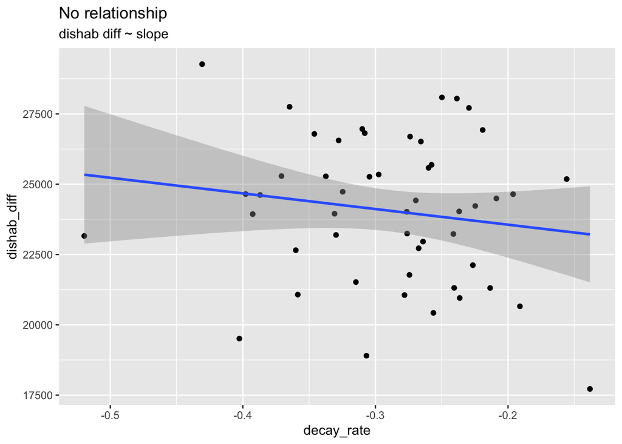

```r
adult_dishab_d %>%
  left_join(adult_slope_df) %>%
  ggplot(aes(x = decay_rate, y = dishab_diff)) +
  geom_point() +
  geom_smooth(method = "lm") +
  labs(
    title = "No relationship",
    subtitle = "dishab diff ~ slope"
  )
```

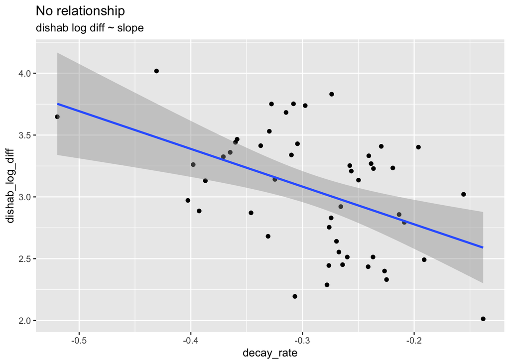

```r
adult_dishab_d %>%
  left_join(adult_slope_df) %>%
  ggplot(aes(x = decay_rate, y = dishab_log_diff)) +
  geom_point() +
  geom_smooth(method = "lm") +
  labs(
    title = "No relationship",
    subtitle = "dishab log diff ~ slope"
  )
```

## 5.2 try modeling??

```r
model_d <- adult_dishab_d %>%
  left_join(adult_slope_df)
lm(
  dishab_diff ~ decay_rate,
  data = model_d
) %>% summary()
```

```
##
## Call:
## lm(formula = dishab_diff ~ decay_rate, data = model_d)
##
## Residuals:
##     Min      1Q  Median      3Q     Max
## -5496.0 -2082.5   151.5  1854.0  4424.7
##
## Coefficients:
##             Estimate Std. Error t value Pr(>|t|)
## (Intercept)    22448       1511   14.86   <2e-16 ***
## decay_rate     -5564       5058   -1.10    0.277
## ---
## Signif. codes:  0 '***' 0.001 '**' 0.01 '*' 0.05 '.' 0.1 ' ' 1
##
## Residual standard error: 2588 on 48 degrees of freedom
## Multiple R-squared:  0.02459,    Adjusted R-squared:  0.004271
## F-statistic:  1.21 on 1 and 48 DF,  p-value: 0.2768
```

```r
lm(
  dishab_log_diff ~ decay_rate,
  data = model_d
) %>% summary()
```

```
##
## Call:
## lm(formula = dishab_log_diff ~ decay_rate, data = model_d)
##
## Residuals:
##      Min       1Q   Median       3Q      Max
## -0.90860 -0.41262  0.00744  0.35261  0.82718
##
## Coefficients:
##             Estimate Std. Error t value Pr(>|t|)
## (Intercept)   2.1680     0.2552   8.494 3.99e-11 ***
## decay_rate   -3.0501     0.8546  -3.569 0.000826 ***
## ---
## Signif. codes:  0 '***' 0.001 '**' 0.01 '*' 0.05 '.' 0.1 ' ' 1
##
## Residual standard error: 0.4373 on 48 degrees of freedom
## Multiple R-squared:  0.2097, Adjusted R-squared:  0.1932
## F-statistic: 12.74 on 1 and 48 DF,  p-value: 0.0008257
```

```r
lm(
  dishab_diff ~ decay_rate + first_trial_looking_time,
  data = model_d
) %>% summary()
```

```
##
## Call:
## lm(formula = dishab_diff ~ decay_rate + first_trial_looking_time,
##     data = model_d)
##
## Residuals:
##     Min      1Q  Median      3Q     Max
## -5728.1 -1794.2   205.1  1862.4  4758.6
##
## Coefficients:
##                            Estimate Std. Error t value Pr(>|t|)
## (Intercept)              18422.3281  4767.7428   3.864 0.000341 ***
## decay_rate               -8631.9034  6128.8893  -1.408 0.165595
## first_trial_looking_time     0.7177     0.8060   0.890 0.377772
## ---
## Signif. codes:  0 '***' 0.001 '**' 0.01 '*' 0.05 '.' 0.1 ' ' 1
##
## Residual standard error: 2594 on 47 degrees of freedom
## Multiple R-squared:  0.04077,    Adjusted R-squared:  -4.504e-05
## F-statistic: 0.9989 on 2 and 47 DF,  p-value: 0.376
```

```r
lm(
  dishab_diff ~  first_trial_looking_time,
  data = model_d
) %>%
  summary()
```

```
##
## Call:
## lm(formula = dishab_diff ~ first_trial_looking_time, data = model_d)
##
## Residuals:
##     Min      1Q  Median      3Q     Max
## -6383.3 -1824.6   263.6  1580.0  5179.2
##
## Coefficients:
##                           Estimate Std. Error t value Pr(>|t|)
## (Intercept)              2.371e+04  2.966e+03   7.995 2.24e-10 ***
## first_trial_looking_time 7.946e-02  6.733e-01   0.118    0.907
## ---
## Signif. codes:  0 '***' 0.001 '**' 0.01 '*' 0.05 '.' 0.1 ' ' 1
##
## Residual standard error: 2620 on 48 degrees of freedom
## Multiple R-squared:  0.0002901,  Adjusted R-squared:  -0.02054
## F-statistic: 0.01393 on 1 and 48 DF,  p-value: 0.9065
```

# 6. Try control by residualized

```r
fake_data_rnr
```

[output not shown]

[output cut: 858 more lines]

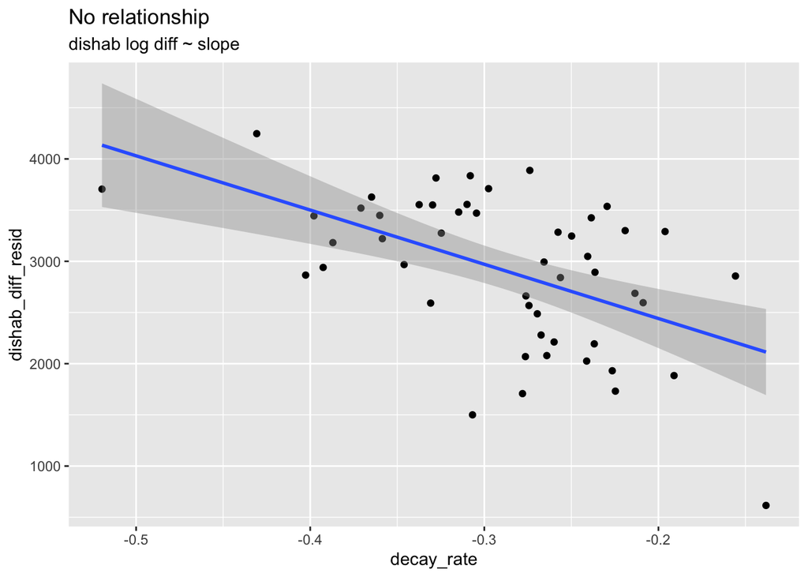

```r
fake_data_rnr$trial_type_numeric <- as.numeric(as.factor(fake_data_rnr$trial_type))


# Define the nonlinear model
exp_decay <- function(trial_number, trial_type_numeric, a, b) {
  a * exp(b * trial_number * trial_type_numeric)
}

# Fit the model
habituation_model <- nlme(
  trial_looking_time ~ exp_decay(trial_number, trial_type_numeric, a, b),
  data = fake_data_rnr,
  fixed = a + b ~ 1,
  random =  b ~ 1 + trial_number | subject,  # Add random intercept
  start = c(a = mean(fake_data_rnr$trial_looking_time),
            b = -0.01),          # Adjust starting values
  control = nlmeControl(msMaxIter = 200, pnlsTol = 1e-6)
)

fake_data_rnr$resid = resid(habituation_model)


adult_dishab_raw <- fake_data_rnr %>%
  filter(trial_number == deviant_position)

adult_dishab_d <- adult_dishab_raw %>%
  select(subject,block_number, resid) %>%
  rename(dishab_raw = resid) %>%
  left_join(
    fake_data_rnr  %>% filter(trial_number < deviant_position) %>% group_by(subject, block_number) %>% filter(trial_number == max(trial_number)),
    by = c("subject", "block_number")
  ) %>%
  # calculating the key
  mutate(
    dishab_diff_resid = dishab_raw - resid) %>%
  mutate(dishab_trial_num = trial_number + 1) %>%
  select(subject, dishab_diff_resid, dishab_trial_num)

adult_dishab_d %>%
  left_join(adult_slope_df) %>%
  ggplot(aes(x = decay_rate, y = dishab_diff_resid)) +
  geom_point() +
  geom_smooth(method = "lm") +
  labs(
    title = "No relationship",
    subtitle = "dishab log diff ~ slope"
  )
```

## 6.1. piece-wise combination

change the model by piece wise combination - this works!

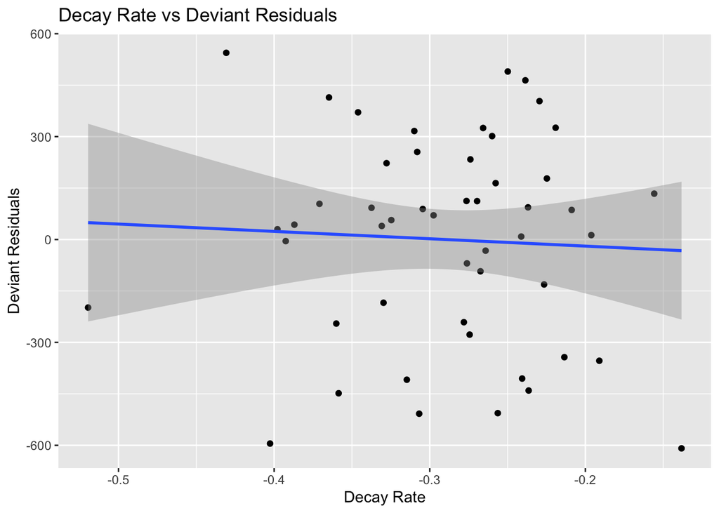

```r
# Separate habituation and deviant trials
habituation_data <- fake_data_rnr %>%
  filter(trial_type == "background")  # Habituation trials only

deviant_data <- fake_data_rnr %>%
  filter(trial_type == "deviant")  # Deviant trial only

# Nonlinear mixed-effects model for habituation trials
habituation_model <- nlme(
  trial_looking_time ~ a * exp(b * trial_number),
  data = habituation_data,
  fixed = a + b ~ 1,                    # Fixed effects for decay
  random = b ~ 1 | subject,         # Random intercept and slope
  start = c(a = mean(habituation_data$trial_looking_time), b = -0.1),        # Initial guesses for parameters
  control = nlmeControl(msMaxIter = 200, pnlsTol = 1e-6)  # Controls for stability
)

deviant_model <- lme(
  trial_looking_time ~ 1,  # Deviant trial modeled as intercept-only
  random = ~ 1 | subject,  # Random intercept to account for subject variability
  data = deviant_data
)

habituation_data$resid_hab <- resid(habituation_model)
deviant_data$resid_dev <- resid(deviant_model)

# Merge the residuals for analysis
combined_residuals <- habituation_data %>%
  select(subject, trial_number, resid_hab) %>%
  bind_rows(
    deviant_data %>%
      select(subject, trial_number, resid_dev) %>%
      rename(resid_hab = resid_dev)
  )


random_effects <- ranef(habituation_model)$b
fixed_decay_rate <- fixef(habituation_model)["b"]
individual_decay_rates <- fixed_decay_rate + random_effects




deviant_resid_data <- deviant_data %>%
  mutate(decay_rate = individual_decay_rates)


ggplot(deviant_resid_data, aes(x = decay_rate, y = resid_dev)) +
  geom_point() +
  geom_smooth(method = "lm") +
  labs(title = "Decay Rate vs Deviant Residuals",
       x = "Decay Rate",
       y = "Deviant Residuals")
```

# 7. do Z score within participant

```r
fake_data_rnr <-  fake_data_rnr %>% group_by(subject) %>%
  mutate(z_score_looking_time = (trial_looking_time - mean(trial_looking_time)) / sd(trial_looking_time)) %>%
  ungroup()


fake_data_rnr
```

```
## # A tibble: 290 × 13
##    subject block_number task_type deviant_position trial_number trial_type
##    <chr>          <dbl> <chr>                <dbl>        <int> <chr>
##  1 S001               1 curiosity                5            1 background
##  2 S001               1 curiosity                5            2 background
##  3 S001               1 curiosity                5            3 background
##  4 S001               1 curiosity                5            4 background
##  5 S001               1 curiosity                5            5 deviant
##  6 S002               1 curiosity                5            1 background
##  7 S002               1 curiosity                5            2 background
##  8 S002               1 curiosity                5            3 background
##  9 S002               1 curiosity                5            4 background
## 10 S002               1 curiosity                5            5 deviant
## # ℹ 280 more rows
## # ℹ 7 more variables: trial_looking_time <dbl>, stimulus_displayed <chr>,
## #   task_question_type <chr>, task_question_response <int>,
## #   trial_type_numeric <dbl>, resid <dbl>, z_score_looking_time <dbl>
```

```r
habituation_data <-  fake_data_rnr %>%
  # fist block
  # before the dishabituation trials
  filter(trial_number < deviant_position) %>%
  # only keeping the relevant information
  select(subject, trial_number, z_score_looking_time) %>%
  rename(trial_looking_time = z_score_looking_time)

adult_slope_df <- get_individual_slope(habituation_data)



adult_dishab_raw <- fake_data_rnr %>%
  filter(trial_number == deviant_position)

adult_dishab_d <- adult_dishab_raw %>%
  select(subject,block_number, z_score_looking_time, trial_looking_time) %>%
  rename(dishab_raw = z_score_looking_time) %>%
  left_join(
    fake_data_rnr  %>% filter(trial_number < deviant_position) %>% group_by(subject, block_number) %>% filter(trial_number == max(trial_number)),
    by = c("subject", "block_number")
  ) %>%
  # calculating the key
  mutate(
    dishab_z_score_diff = dishab_raw - z_score_looking_time) %>%
  mutate(dishab_trial_num = trial_number + 1) %>%
  select(subject, dishab_z_score_diff, dishab_trial_num)
```

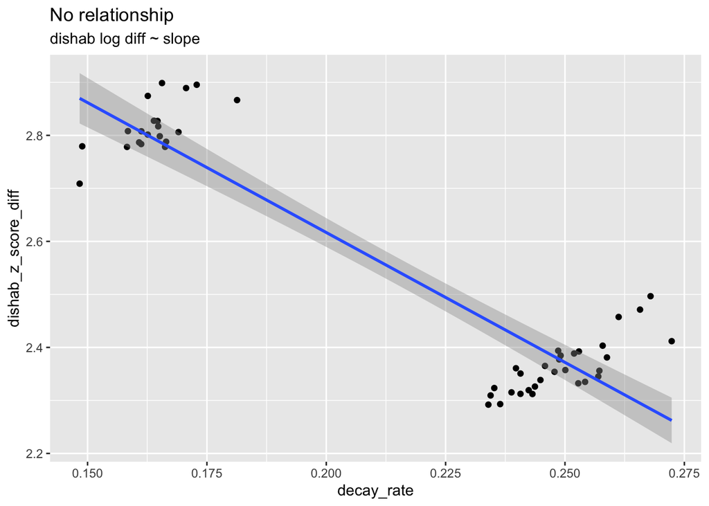

```r
adult_dishab_d %>%
  left_join(adult_slope_df) %>%
  ggplot(aes(x = decay_rate, y = dishab_z_score_diff)) +
  geom_point() +
  geom_smooth(method = "lm") +
  labs(
    title = "No relationship",
    subtitle = "dishab log diff ~ slope"
  )
```

# 8. Try to see if the piece-wise destroy the constructed relationship?

no – if there’s a real realtionship it’s still there!

```r
# Generate synthetic data
generate_fake_data <- function(n_subjects = 50) {
  # Create subject IDs
  subjects <- paste0("S", sprintf("%03d", 1:n_subjects))

  # Initialize empty data frame
  data <- data.frame()

  # Loop through each subject
  for (subj in subjects) {
    # Randomly assign number of habituation trials (4 or 6)
    n_trials <- sample(c(4, 6), 1)
    trial_number <- 1:(n_trials + 1)

    # Simulate exponential drop in habituation times with varying slopes
    initial_looking_time <- runif(1, 5000, 10000)
    decay_rate <- runif(1, 0.2, 0.5)  # Randomly vary decay rate
    habituation_times <- initial_looking_time * exp(-decay_rate * (1:n_trials))
    deviant_time <- 10000 * decay_rate + rnorm(1, 0, 500)  # Linearly related to the decay slope

    # Combine looking times
    trial_looking_time <- c(habituation_times, deviant_time)

    # Assign trial types
    trial_type <- c(rep('background', n_trials), 'deviant')

    # Create data frame for subject
    subject_data <- data.frame(
      subject = subj,
      block_number = 1,
      task_type = 'curiosity',
      deviant_position = n_trials + 1,
      trial_number = trial_number,
      trial_type = trial_type,
      trial_looking_time = trial_looking_time,
      stimulus_displayed = paste0('images/stimuli/', sample(1:20, n_trials + 1, replace = TRUE), '_A_a.gif'),
      task_question_type = 'curiosity_background',
      task_question_response = sample(1:5, n_trials + 1, replace = TRUE)
    )

    # Append subject data
    data <- rbind(data, subject_data)
  }

  return(data)
}

# Generate dataset
fake_data_slope <- generate_fake_data(n_subjects = 50)
```

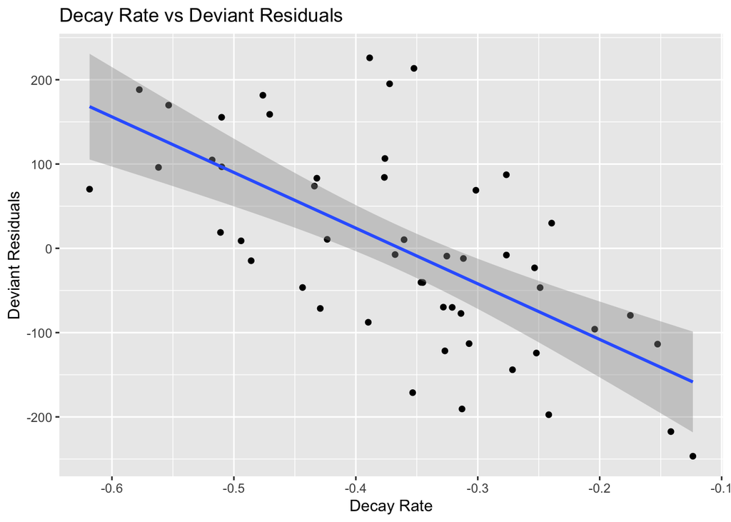

```r
# Separate habituation and deviant trials
habituation_data <- fake_data_slope %>%
  filter(trial_type == "background")  # Habituation trials only

deviant_data <- fake_data_slope %>%
  filter(trial_type == "deviant")  # Deviant trial only

# Nonlinear mixed-effects model for habituation trials
habituation_model <- nlme(
  trial_looking_time ~ a * exp(b * trial_number),
  data = habituation_data,
  fixed = a + b ~ 1,                    # Fixed effects for decay
  random = b ~ 1 | subject,         # Random intercept and slope
  start = c(a = mean(habituation_data$trial_looking_time), b = -0.1),        # Initial guesses for parameters
  control = nlmeControl(msMaxIter = 200, pnlsTol = 1e-6)  # Controls for stability
)

deviant_model <- lme(
  trial_looking_time ~ 1,  # Deviant trial modeled as intercept-only
  random = ~ 1 | subject,  # Random intercept to account for subject variability
  data = deviant_data
)

habituation_data$resid_hab <- resid(habituation_model)
deviant_data$resid_dev <- resid(deviant_model)

# Merge the residuals for analysis
combined_residuals <- habituation_data %>%
  select(subject, trial_number, resid_hab) %>%
  bind_rows(
    deviant_data %>%
      select(subject, trial_number, resid_dev) %>%
      rename(resid_hab = resid_dev)
  )


random_effects <- ranef(habituation_model)$b
fixed_decay_rate <- fixef(habituation_model)["b"]
individual_decay_rates <- fixed_decay_rate + random_effects




deviant_resid_data <- deviant_data %>%
  mutate(decay_rate = individual_decay_rates)


ggplot(deviant_resid_data, aes(x = decay_rate, y = resid_dev)) +
  geom_point() +
  geom_smooth(method = "lm") +
  labs(title = "Decay Rate vs Deviant Residuals",
       x = "Decay Rate",
       y = "Deviant Residuals")
```